# Итоговый проект

Группа 1

```r
library(recommenderlab)
library(igraph)
library(ggraph)
library(ggplot2)
library(ggforce)
library(concaveman)
library(tidyverse)
library(tidytext)
library(tidygraph)
library(stopwords)
library(tm)
library(textstem)
library(corpus)
library(wordcloud2)
load("~/shared/minor2_2020/data/good_read/books_g_1.RData")
load("~/shared/minor2_2020/data/good_read/reviews_g_1.RData")
```

### Предобработка

#### Анализ описаний комиксов

*Анализ встречаемости слов в описании*

```r
# проведем лемматизацию
goodread_comics$lem = lemmatize_strings(goodread_comics$description)
df_tidy <- goodread_comics %>%
  select(book_id, lem) %>%
  unnest_tokens(words, lem)


#Удалим стоп-слова, которые не нужны для дальнейшего анализа (отражают того, кто составлял описание, а не автора)
engtopwords = data.frame(words=stopwords("en"), stringsAsFactors=FALSE)
df.nonstop = df_tidy %>%
    anti_join(engtopwords)
df_tidy <- df_tidy %>% anti_join(engtopwords)
head(df_tidy)
```

```
##     book_id    words
## 1: 28533221   kieron
## 2: 28533221   gillen
## 3: 28533221    jamie
## 4: 28533221 mckelvie
## 5: 28533221  matthew
## 6: 28533221   wilson
```

```r
tidy = df_tidy
```

```r
df_tidy %>%
    dplyr::select(words) %>%
    n_distinct()
```

```
## [1] 7909
```

В нашем датасете 7909 различных слов

```r
df.nonstop.counts = df.nonstop %>%
    dplyr::count(words, sort=TRUE) %>%
    top_n(50, n)

wordcloud2(data = df.nonstop.counts)
```

[interactive chart not shown]

Наиболее популярные слова являются довольно стандартными для описания комиксов: “new”(“новый”), “book” (“книга”), “comics” (“комикс”), “story”(“история”) и другие. Большинство слов так или иначе связаны с командой, друзьями, героями, их жизнью, можно сделать вывод, что большинство комиксов описывает именно это.

Построим матрицу схожести описаний комиксов.

```r
comics_tdm <- df_tidy %>% group_by(book_id) %>% count(words, sort=TRUE) %>% cast_sparse(book_id, words, n) %>%
  as.matrix()
df_styl <- lsa::cosine(t(comics_tdm))
```

*Sentiment analysis описаний*

Проведем сентимент-анализ описаний, чтобы понять, как эмоционально окрашены комиксы, и можно ли использовать их для рекомендательной системы.

```r
for_corp <- goodread_comics %>% select(title, description)
names(for_corp) <- c("title", "text")


df_corpus <- as_corpus_frame(for_corp)

text_filter(df_corpus)$drop_punct <- TRUE
text_filter(df_corpus)$drop_number <- TRUE

text_tokens(df_corpus[120,])
```

```
## $`120`
##  [1] "when"            "a"               "force"           "even"
##  [5] "greater"         "than"            "the"             "all-powerful"
##  [9] "former"          "superhero"       "plutonian"       "comes"
## [13] "to"              "earth"           "will"            "it"
## [17] "finally"         "be"              "the"             "savior"
## [21] "the"             "world"           "has"             "been"
## [25] "waiting"         "for"             "or"              "will"
## [29] "it"              "prove"           "to"              "be"
## [33] "an"              "even"            "bigger"          "threat"
## [37] "see"             "what"            "everyone"        "is"
## [41] "talking"         "about"           "in"              "this"
## [45] "eisner"          "and"             "harvey"          "award-nominated"
## [49] "superhero"       "series"          "from"            "comic"
## [53] "book"            "legend"          "mark"            "waid"
```

```r
term_stats(df_corpus, ngrams = 4) #count - сколько раз встречается, support - во скольких текстах встречается
```

```
##    term                              count support
## 1  for the first time                   13      13
## 2  one of the most                       7       6
## 3  issues of the hit                     6       6
## 4  of the hit series                     6       6
## 5  with the help of                      6       6
## 6  buffy the vampire slayer              5       5
## 7  issues # of the                       5       5
## 8  dc comics the new                     6       4
## 9  a matter of months                    4       4
## 10 a part of the                         4       4
## 11 a world ruled by                      4       4
## 12 an epidemic of apocalyptic            4       4
## 13 and feed on the                       4       4
## 14 apocalyptic proportions has swept     4       4
## 15 are forced to finally                 4       4
## 16 as a part of                          4       4
## 17 as they try to                        4       4
## 18 as well as the                        4       4
## 19 at the end of                         4       4
## 20 at the hands of                       4       4
## ⋮  (42518 rows total)
```

```r
stats <- text_stats(df_corpus)

term_stats(df_corpus, subset = !term %in% stopwords_en)
```

```
##    term       count support
## 1  new          238     159
## 2  one          148     119
## 3  collecting   117     117
## 4  world        128     101
## 5  first         96      86
## 6  can           88      80
## 7  series        97      78
## 8  time          91      77
## 9  now           85      77
## 10 #            108      76
## 11 story         78      64
## 12 find          65      62
## 13 life          72      61
## 14 collects      62      61
## 15 book          69      56
## 16 back          62      56
## 17 comics        76      52
## 18 must          52      49
## 19 just          56      48
## 20 team          54      47
## ⋮  (9520 rows total)
```

```r
affect_wordnet
```

```
##    term             pos  category emotion
## 1  jollity          NOUN Joy      Positive
## 2  joviality        NOUN Joy      Positive
## 3  chaff            VERB Joy      Positive
## 4  kid              VERB Joy      Positive
## 5  banter           VERB Joy      Positive
## 6  jolly            VERB Joy      Positive
## 7  merry            ADJ  Joy      Positive
## 8  jovial           ADJ  Joy      Positive
## 9  jolly            ADJ  Joy      Positive
## 10 jocund           ADJ  Joy      Positive
## 11 gay              ADJ  Joy      Positive
## 12 mirthful         ADJ  Joy      Positive
## 13 riotously        ADV  Joy      Positive
## 14 exuberantly      ADV  Joy      Positive
## 15 expansively      ADV  Joy      Positive
## 16 ebulliently      ADV  Joy      Positive
## 17 exuberance       NOUN Joy      Positive
## 18 lightheartedness NOUN Joy      Positive
## 19 carefreeness     NOUN Joy      Positive
## 20 lightsomeness    NOUN Joy      Positive
## ⋮  (1641 rows total)
```

```r
affect <- subset(affect_wordnet, emotion != "Neutral") #Нейтральные эмоции не будут полезными для анализа, поэтому было решено их убрать

affect$emotion <- droplevels(affect$emotion)
affect$category <- droplevels(affect$category)

term_stats(df_corpus, subset = term %in% affect$term) # показывает стилистически окрашенные слова в описаниях (важно!)
```

```
##    term   count support
## 1  dark      51      45
## 2  love      46      36
## 3  like      45      34
## 4  black     48      33
## 5  down      32      30
## 6  evil      31      27
## 7  good      22      21
## 8  still     18      18
## 9  great     17      16
## 10 hope      16      16
## 11 horror    18      14
## 12 bad       14      14
## 13 heart     13      13
## 14 defeat    11      11
## 15 fear      10      10
## 16 proud     10      10
## 17 scene      9       9
## 18 alien      8       8
## 19 cold       8       8
## 20 mad        8       8
## ⋮  (232 rows total)
```

```r
text_sample(df_corpus, 'still')
```

```
##    text             before              instance              after
## 1  420  …'s a mom now, Jessica Drew is   still    kicking ass and taking names …
## 2  430                                   Still    on the run from their super-v…
## 3  197  …att Murdock takes a new case!   Still    reeling from the conclusion o…
## 4  72   …ittle ancient British village   still    holds out against the Roman i…
## 5  229  …whimsical stories, and yet he   still    offers timeless insight into …
## 6  23   …sumed-dead Green Lanterns are   still    alive!\nCollecting: Green Lan…
## 7  257  …Deadpool's style. Though he's   still    committed to doing this "hero…
## 8  98   …orld will she manage that and   still    manage to stay alive?!
## 9  128  …ful girl from the Laundromat,   still    single? How can you, the read…
## 10 438  …ed to Isaiah? Can Black Widow   still    turn to the Avengers, or even…
## 11 271  …evotes himself solely to her.   Still   , one cannot help but long for…
## 12 306  …the beginning, and Buffy must   still    face the ultimate betrayal.\n…
## 13 12   …o find the one thing that can   still    scare them all: campfire stor…
## 14 55   …lowing her around? And is she   still    going out with Kyle? P.S. Did…
## 15 363  … empty. She is miserable, but   still    attending a preparatory schoo…
## 16 332  … for the ruthless enemy who's   still    lurking in the back woods. Th…
## 17 178  …body count is rising! Are you   still    game?
## 18 421  …ut with Catwoman and Two-Face   still    on the loose, Strange will go…
```

```r
text_sample(df_corpus, 'cold') # в основном употребляется про Холодную войну
```

```
##   text             before              instance              after
## 1 380  …the bride-to-be, even he gets    cold    feet. If Wade won't run this g…
## 2 168  …the Winter Soldier during the    Cold    War - has come to the U.S., an…
## 3 489  …o her death. Beginning in the    cold    streets of a heartless metropo…
## 4 386  …he Secret 7, SHAZAM!, Citizen    Cold    and other new and familiar, ye…
## 5 478  … preternatural winter. If the    cold    doesn't kill them, the hideous…
## 6 221  …ition!\nIn this vivid tale of    Cold    War paranoia, the ship carryin…
## 7 495  …aw Diana take a man's life in    cold    blood, and her subsequent tria…
## 8 87   …an exciting life - first as a    Cold    War-era Soviet spy, followed b…
```

```r
text_sample(df_corpus, 'great')
```

```
##    text             before              instance              after
## 1  497  … all lives on the edge of the   great    forest.\nNeil Gaiman and Lore…
## 2  374  …sively seeking revenge on the   great    white whale that took his leg…
## 3  342  …nd of rubble and anarchy, the   Great    Tokyo Empire rises, a ragtag …
## 4  475  … Book Club. Also features the   Great    Plastic Coffee Cup Lid Challe…
## 5  359  …ship with Spike. Seems like a   great    time for a new Big Bad to mak…
## 6  33   … final stage, but not without   great    cost to Faith... And not with…
## 7  332  … Last Castle, we learn of the   great    war that forced Bigby Wolf, P…
## 8  368  …ght Care Nursery seems like a   great    idea, until she is magically …
## 9  295  …omeworld, where everything is   great    -- if you possess the mutant …
## 10 84   …t the ages - men and women of   great    courage, valor, skill, and sa…
## 11 254  … daughter of Arcopolis's last   great    hero, Haggard West.\nA preque…
## 12 374  …oute retells the story of the   Great    American Novel. Captain Ahab …
## 13 20   …ey starting with the end of a   great    war in the stars and the begi…
## 14 264  …ir, where the elements are as   great    a threat as the enemy. No wea…
## 15 287  …place; her foster parents are   great    and all, but she's long felt …
## 16 76    London's elite society places   great    importance on class differenc…
## 17 282  …eroes Eventually Known as the   Great    Lakes Initiative Plus: The Me…
```

```r
text_sample(df_corpus, 'like') # используется больше для сравнения
```

```
##    text             before              instance              after
## 1  52   …y has risen across the cosmos    like    a plague, destroying everythi…
## 2  416  … next door decided she didn't    like    Gloria's guitar playing . . .…
## 3  456  …inal graphic novel that reads    like    an extended episode! What It …
## 4  136  …l technique\nThis is The Crow    like    you've never seen it before--…
## 5  210  …ving never operated a machine    like    this, what are the chances he…
## 6  206  …ring readers Batman and Robin    like    they've never seen before, in…
## 7  228  …eaten America's greatest hero    like    never before. Will the Sentin…
## 8  359  …elationship with Spike. Seems    like    a great time for a new Big Ba…
## 9  459  …mbering what a triangle looks    like   . Helping her through life's u…
## 10 236  …ings and can fly. It may seem    like    a dream come true to some, bu…
## 11 220  …stined to be a monster-hunter    like    her Van Helsing ancestor, and…
## 12 240  … who move through the shadows    like    ghosts. On the streets of San…
## 13 203  …ades? Are they in love, lust,    like   , or just lame? Sexy fun times…
## 14 77   … When you're an angry old man    like    Earl Tubb, the only way to su…
## 15 78   …he gets motion sickness, eats    like    a pig, and his best friend is…
## 16 274  …! It's a vision of the future    like    none you'e ever seen before! …
## 17 459  …he Onion\n"...it really seems    like    the inheritor of 'Calvin and …
## 18 77   …e only way to survive a place    like    this...is to carry a really b…
## 19 315  …hat. Because Rue is a faerie,    like    her mother was. And her fathe…
## 20 159  … monster-killing epic that is    like    Buffy meets Tank Girl in a Lo…
## ⋮  (45 rows total)
```

```r
text_sample(df_corpus, 'heart') # больше как "душевный", поэтому решил оставить
```

```
##    text             before              instance              after
## 1  6    …n't count on anything but his   heart    and a stranger's voice to gui…
## 2  363  … a huge emotional scar in her   heart   . Due to an accident, she lost…
## 3  22   …s for the future of the human   heart   . Because it was never the com…
## 4  109  …t behind the act is a genuine   heart    driven to succeed. Yukino is …
## 5  129  … standstill as they reach the   heart    of Metropolis. Going punch fo…
## 6  71   …hronism and Bloodstone, whose   heart    will get broken - or stopped?…
## 7  345  …rld.Arcadia's quest is at the   heart    of this new title from writer…
## 8  152  …. Now, Day brings the wit and   heart    of the show to this graphic-n…
## 9  282  … horrific hero stabbed in the   heart    both figuratively and literal…
## 10 32   …conspiracy involving the very   heart    of the British Establishment,…
## 11 352  …he dark magic that lay at the   heart    of this fable. Since then, it…
## 12 501  …oe. Should she be true to her   heart    or cut Tomoe loose for his ow…
## 13 440  …s doesn't skirt issues at the   heart    of the matter such as insecur…
```

```r
affect <- subset(affect, !term %in% c("still", "like", "cold")) #Решил убрать, поскольку они несут двойной смысл
```

Видно, что в основном описания тайтлов окрашены негативно, много слов таких как “evil”, “defeat”, “horror”, и др.

```r
# тут дана оценка слов в описаниях к различным тайтлам
df_sent <- df_tidy %>% inner_join(affect, by=c("words" = "term"))
```

```r
term_scores <- with(affect, unclass(table(term, emotion)))

ncat <- rowSums(term_scores > 0)
term_scores[ncat > 1, c("Positive", "Negative", "Ambiguous")] <- c(0, 0, 1)

term_scores[term_scores > 1] <- 1
chunks <- text_split(df_corpus, "tokens", 150)
(n <- text_ntoken(chunks))
```

```
##   [1]  42  94  93  65  84  92  91  50  84  74 100  12 106 106  62  59 117 119
##  [19]  43 111 111 120  38  58  77 149  38  29 103   0  46 133  41  63 134 131
##  [37] 131 131 124 147  96  65  50 110  68  98  89  10  96 130   3  79 102  80
##  [55]  44   0  89  89  82  81 107 130  92  48 110  34  81  76  76  63  85 113
##  [73]  91  53 105  85  81  81 130 114  77  45 145  79  78  59  52  88   0 145
##  [91]  89   0 115 120  65  15 134  89  91 136  46  62  85  84  91  84 106  93
## [109] 125  51   0 123 134  65   0  58 124  37  87  87 138  90 110 107 107   7
## [127] 138 112 111  33  63   0  56 114 113 102 103  87 123  37  80  80 148 102
## [145] 135  96  92 126  55  99  77  76 116 144 108  95   0  47 140  45   9  58
## [163] 130   0   0  80  90 116 140  87 139  76  76  63  74 128  61 135  94  94
## [181]  87   0  96  43 129 128  85 123  94 133  59  27  57  38  94  38 102 141
## [199] 129 134  77  76  85  85 131 123 145   0   0  93   0  97 116  82  16  61
## [217] 116  68  79   0 119  25 142  53  73 115  33  30 129 104 100  99 101  92
## [235]  92  54  41 134 115  46  98   4  40  75 117  86  85  62  77 149 149 129
## [253] 113 112 116  37  76  85  43 108  94  93  45  86  86 121  99  44  94  81
```

[output cut: 16 more lines]

```r
x <- term_matrix(chunks, select = rownames(term_scores))
text_scores <- x %*% term_scores
```

```r
unit <- 1000
rate <- list(pos = text_scores[, "Positive"] / n * unit,
             neg = text_scores[, "Negative"] / n * unit,
             ambig = text_scores[, "Ambiguous"] / n * unit)
rate$total <- rate$pos + rate$neg + rate$ambig
```

```r
se <- lapply(rate, function(r) sqrt(r * (unit - r) / n))
```

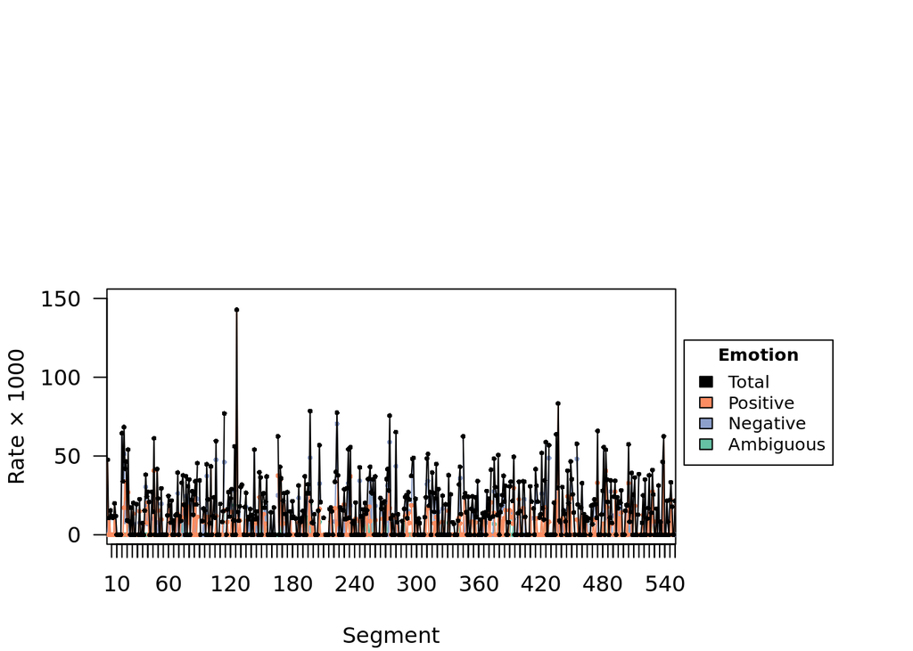

```r
# set up segment IDs
i <- seq_len(nrow(chunks))

# set the plot margins, with extra space below the plot
par(mar = c(4, 4, 11, 9) + 0.1, las = 1)

# set up the plot coordinates; put labels but no axes
xlim <- range(i - 0.5, i + 0.5, 10)
ylim <- range(0, 150, 15)
plot(xlim, ylim, type = "n", xlab = "Segment", ylab = "Rate \u00d7 1000", axes = FALSE,
     xaxs = "i")
usr <- par("usr") # get the user coordinates for later

# put tick marks at multiples of 5 on the x axis; labels at multiples of 10
axis(1, at = i[i %% 5 == 0], labels = FALSE)
axis(1, at = i[i %% 10 == 0], labels = TRUE)

# defaults for the y axis
axis(2)

# put vertical lines at chapter boundaries
#abline(v = tapply(i, chunks$parent, min) - 0.5, col = "gray")

# put chapter titles above the plot
#labels <- goodread_comics$book_id
#at <- tapply(i, chunks$parent, mean)

# (adapted from https://www.r-bloggers.com/rotated-axis-labels-in-r-plots/)
#text(at, usr[4] + 0.01 * diff(usr[3:4]),
#     labels = labels, adj = 0, srt = 45, cex = 0.5, xpd = TRUE, pch=1)

# frame the plot
box()

# colors for the different emotions, from RColorBrewer::brewer.pal(3, "Set2")
col <- c(total = "#000000", pos = "#FC8D62", neg = "#8DA0CB", ambig = "#66C2A5")

# add a legend on the right hand side
legend(usr[2] + 0.015 * diff(usr[1:2]), usr[3] + 0.8 * diff(usr[3:4]),
       legend = c("Total", "Positive", "Negative", "Ambiguous"),
       title = expression(bold("Emotion")),
       fill = col[c("total", "pos", "neg", "ambig")],
       cex = 0.8, xpd = TRUE)

# for the total rate, put a dashed line at the mean rate
#abline(h = mean(rate$total), lty = 2, col = col[["total"]])

# plot each rate type
for (t in c("ambig", "neg", "pos", "total")) {
    r <- rate[[t]]
    s <- se[[t]]
    cl <- col[[t]]

    # add lines and points
    lines(i, r, col = cl)
    points(i, r, col = cl, pch = 16, cex = 0.5)
    }
```

# TF-IDF

```r
words_count = df_tidy %>% count(words)

words_count = words_count %>%
  filter(n > 5 & n < quantile(words_count$n, 0.95))

df_tidy = df_tidy %>%
  filter(words %in% words_count$words)

df_count = df_tidy %>%
    count(book_id) %>%
    filter(n > 5)

df_tf_idf = df_tidy %>%
    filter(book_id %in% df_count$book_id) %>%
    count(book_id, words) %>%
    bind_tf_idf(words, book_id, n)

# df_new_count создан исключительно для построения облака слов из почищеннного датасета (убраны стоп-слова и самые редкие/самые частые)
df_new_count = df_tidy %>%
    dplyr::count(words, sort=TRUE) %>%
    top_n(50, n)

wordcloud2(data = df_new_count, size=.2)
```

[interactive chart not shown]

```r
#Матрица встречаемости слов
reviews.tdm = df_tf_idf %>%
    dplyr::select(book_id, words, tf_idf) %>%
    pivot_wider(names_from = words,
                values_from = tf_idf,
                values_fill = 0)
```

```r
text_scores
```

```
## 550 x 3 Matrix of class "dgeMatrix"
##        Positive Negative Ambiguous
##   [1,]        2        0         0
##   [2,]        0        1         0
##   [3,]        1        0         0
##   [4,]        0        1         0
##   [5,]        0        1         0
##   [6,]        0        1         0
##   [7,]        0        1         0
##   [8,]        1        0         0
##   [9,]        0        1         0
##  [10,]        0        0         0
##  [11,]        0        0         0
##  [12,]        0        0         0
##  [13,]        0        0         0
```

[output cut: 537 more lines]

*LDA анализ описаний*

Выделим 4 темы описаний комиксов, чтобы понять, о чем они

```r
library(LDAvis)
library(topicmodels)
tidy_new <- tidy %>%
  count(book_id, words, sort = TRUE) %>%
  ungroup()

tidy_dtm <- tidy_new %>%
  cast_dtm(book_id, words, n) #преобразовываем таблицу в матрицу

tidy_lda <- LDA(tidy_dtm, k = 4, control = list(seed = 12345)) #матрица, количество тем, контроль за вероятностью
tidy_lda
```

```
## A LDA_VEM topic model with 4 topics.
```

```r
tidy_topics <- tidy(tidy_lda, matrix = "beta") # извлекаем матрицу
tidy_topics
```

```
## # A tibble: 31,636 x 3
##    topic term       beta
##    <int> <chr>     <dbl>
##  1     1 de    1.27e- 16
##  2     2 de    1.47e-  2
##  3     3 de    3.84e- 25
##  4     4 de    2.16e- 26
##  5     1 la    7.59e- 13
##  6     2 la    9.33e-  3
##  7     3 la    2.60e- 28
##  8     4 la    9.60e- 23
##  9     1 wine  3.36e-145
## 10     2 wine  1.24e-141
## # … with 31,626 more rows
```

Посмотрим на популярные слова в каждой теме

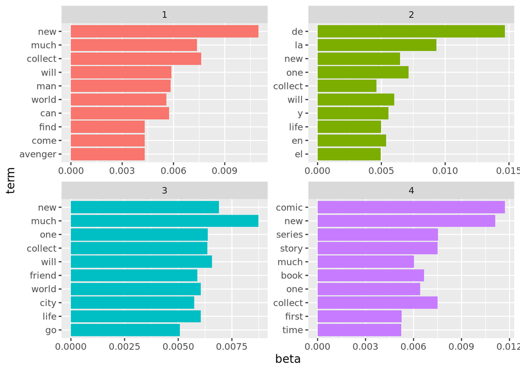

```r
tidy_top_terms <- tidy_topics %>%
  group_by(topic) %>%
  top_n(10, beta) %>% #отобрали 10 слов в каждой группе
  ungroup() %>%
  arrange(topic, -beta)

tidy_top_terms %>%
  mutate(term = reorder(term, beta)) %>%
  ggplot(aes(term, beta, fill = factor(topic))) +
  geom_col(show.legend = FALSE) +
  facet_wrap(~ topic, scales = "free") +
  coord_flip()
```

Посмотрим, как темы распределяются по отзывам. Получим вероятности того, что документ относится к той или иной теме (per-document-per-topic probabilities).

```r
tidy_documents <- tidy(tidy_lda, matrix = "gamma")
tidy_documents_wide = pivot_wider(tidy_documents, names_from = topic, values_from = gamma)
```

Распределение отзывов по темам

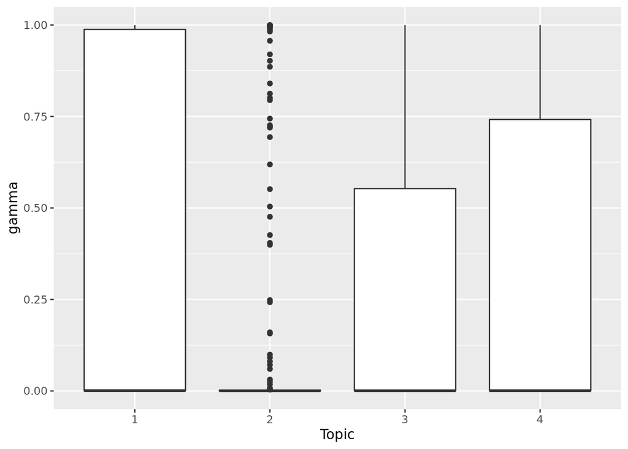

```r
ggplot(data = tidy_documents, aes(x = factor(topic), y = gamma)) +
  geom_boxplot()+
  xlab("Topic")
```

Вероятность, что комикс относится к определенной темы в большинстве случаев очень мала, только у малого количества комиксов сильно выражана какая-то определенная тема, поэтому мы не будем использовать темы при построении рекомендательных систем.

*Вывод*: Текстовый анализ описаний не принес значительных результатов, которые можно использовать в рекомендательных системах.

#### Анализ отзывов на комиксы

*Анализ встречаемости слов*

```r
names(goodread_reviews) <- c("book_id", "review_id", "user_id", "date_added", "rating", "text")

goodread_reviews$lem = lemmatize_strings(goodread_reviews$text)

df_tidy_reviews <-goodread_reviews %>% unnest_tokens(words, lem)
```

```r
df_nonstop_reviews = df_tidy_reviews %>%
    anti_join(engtopwords)
```

```r
library(wordcloud2)

df.nonstop.counts_reviews = df_nonstop_reviews %>%
    dplyr::count(words, sort=TRUE) %>%
    top_n(50, n)

wordcloud2(data = df.nonstop.counts_reviews)
```

[interactive chart not shown]

```r
words_count_reviews = df_nonstop_reviews %>%
  dplyr::count(words)

#удалим слишком редкие и наоборот, слишком распространенные
words_count_reviews = words_count_reviews %>%
  filter(n > 5 & n < quantile(words_count_reviews$n, 0.95))

df_nonstop_reviews = df_nonstop_reviews %>%
  filter(words %in% words_count_reviews$words)
```

```r
reviews_count = df_nonstop_reviews %>%
    dplyr::count(review_id) %>%
    filter(n > 5)

# для оставшихся отзывов посчитаем метрику TF-IDF
reviews_tf_idf = df_nonstop_reviews %>%
    filter(review_id %in% reviews_count$review_id) %>%
    dplyr::count(review_id, words) %>%
    bind_tf_idf(words, review_id, n)


library(tidyr)
reviews.tdm = reviews_tf_idf %>% group_by(review_id) %>% cast_sparse(review_id, words, tf_idf) %>%
  as.matrix()

#df_styl <- lsa::cosine(t(reviews.tdm))   # похожесть по частотам tf-idf, наверное, лучший показатель для построения рек системы(будет долго выполняться)
```

Посмотрим на биграммы

```r
for_corp <- goodread_reviews %>% select(review_id, text)
for_corp$text <- as.character(for_corp$text)

df_corpus <- corpus_frame(goodread_reviews$review_id, text=goodread_reviews$text)

text_filter(df_corpus)$drop_punct <- TRUE
text_filter(df_corpus)$drop_number <- TRUE


term_stats(df_corpus, subset = !term %in% stopwords_en)
```

```
##    term       count support
## 1  story       7355    4237
## 2  read        5086    3511
## 3  like        5109    3180
## 4  one         4973    3174
## 5  really      4562    2979
## 6  book        5068    2929
## 7  just        4234    2729
## 8  good        3124    2440
## 9  series      3716    2413
## 10 art         2652    2117
## 11 characters  2950    2064
## 12 much        2703    2061
## 13 first       2725    1977
## 14 great       2331    1856
## 15 volume      2876    1826
## 16 love        2701    1779
## 17 get         2302    1744
## 18 also        2360    1722
## 19 well        2178    1686
## 20 time        2162    1590
## ⋮  (49969 rows total)
```

```r
term_stats(df_corpus, ngrams = 2, types = TRUE,
           subset = !type1 %in% stopwords_en & !type2 %in% stopwords_en)  # получаются интересные биграммы
```

```
##    term            type1   type2   count support
## 1  graphic novel   graphic novel    1432    1090
## 2  graphic novels  graphic novels    490     414
## 3  comic book      comic   book      403     335
## 4  feel like       feel    like      311     285
## 5  first volume    first   volume    310     271
## 6  really enjoyed  really  enjoyed   274     264
## 7  felt like       felt    like      267     245
## 8  looking forward looking forward   244     239
## 9  even though     even    though    255     236
## 10 pretty good     pretty  good      200     192
## 11 next volume     next    volume    196     191
## 12 spoiler alert   spoiler alert     173     171
## 13 really good     really  good      174     167
## 14 really liked    really  liked     167     161
## 15 art style       art     style     162     148
## 16 really like     really  like      157     147
## 17 well done       well    done      155     145
## 18 first time      first   time      151     144
## 19 wonder woman    wonder  woman     231     139
## 20 story line      story   line      145     139
## ⋮  (203084 rows total)
```

```r
text_locate(df_corpus, "recommend", stemmer = "en")
```

```
##    text           before               instance                after
## 1  10                graphic novel    recommended    by Tara
## 2  20   … with real depth. I can't     recommend     this enough.
## 3  37   … vol 1", Goodreads had it    recommended    to me, three different tim…
## 4  51   …omic book obsessed friend    recommended    I start with this book...a…
## 5  127  …art is beautiful. I would     recommend     to anyone who likes shonen…
## 6  168  …t Manga series they would     recommend     for a person, well, like m…
## 7  168  …. This was the series she    recommended   . This is my fourth Manga s…
## 8  168  …th Manga series. (I would     recommend     DeathNote to anyone who wa…
## 9  173  … because many people have    recommended    it to me. After finishing,…
## 10 180  … >_< \n But yes, I highly     recommend     this one :-) I still stumb…
## 11 191  …hat note, I'm still gonna     recommend     this volume to anyone who …
## 12 198    see review of Volume 1 -    recommended   !!
## 13 201  …out and well done. Highly    recommended   .
## 14 204  … do you want more musical  recommendations ? \n * who am I talking to,…
## 15 214  …f anyone can give me more  recommendations  for Manga I would apprecia…
## 16 222  … it then the other one. I     recommend     keep going! I know I will.…
## 17 236  …ve in store for Sarah? \n     Recommend    .
## 18 244  …big one. \n All-in-all, I     recommend     this book to anyone who is…
## 19 261  …onestly I wouldn't really     recommend     it.
## 20 283  …se imagery, then I highly     recommend     it.
## ⋮  (706 rows total)
```

```r
reviews.bigrams = goodread_reviews %>%
  unnest_tokens(bigram, lem, token = "ngrams", n = 2)

reviews.bifiltered = reviews.bigrams %>%
  separate(bigram, c("word1", "word2"), sep = " ") %>%
  dplyr::filter(!word1 %in% stopwords_en) %>%
  dplyr::filter(!word2 %in% stopwords_en)

reviews.bifiltered %>%
  dplyr::select(word1, word2) %>%
  dplyr::count(word1, word2, sort = TRUE)
```

```
## # A tibble: 195,447 x 3
##    word1   word2       n
##    <chr>   <chr>   <int>
##  1 graphic novel    1931
##  2 feel    like      745
##  3 comic   book      534
##  4 x       man       397
##  5 really  enjoy     376
##  6 look    forward   346
##  7 spider  man       338
##  8 really  like      332
##  9 first   volume    312
## 10 much    much      278
## # … with 195,437 more rows
```

```r
reviews.bifiltered %>%
  dplyr::select(rating, word1, word2) %>%
  filter(rating>=4)
```

```
## # A tibble: 196,553 x 3
##    rating word1     word2
##     <dbl> <chr>     <chr>
##  1      4 seriously spot
##  2      4 runaway   teenager
##  3      4 witness   something
##  4      4 something much
##  5      4 slightly  traumatic
##  6      4 good      thing
##  7      4 kinda     low
##  8      4 even      though
##  9      4 fan       freak
## 10      4 freak     tastic
## # … with 196,543 more rows
```

Получившиеся биграммы можно использовать в рекомендациях. Например, если выделить такие биграммы как realy liked, really enjoyed, etc.

*Sentiment analysis отзывов*

```r
affect <- subset(affect_wordnet, emotion != "Neutral")
affect$emotion <- droplevels(affect$emotion) # drop the unused "Neutral" level
affect$category <- droplevels(affect$category) # drop unused categories
```

```r
term_stats(df_corpus, subset = term %in% affect$term)
```

```
##    term      count support
## 1  like       5109    3180
## 2  good       3124    2440
## 3  great      2331    1856
## 4  love       2701    1779
## 5  still      1990    1576
## 6  bad         921     748
## 7  down        803     678
## 8  dark        697     555
## 9  enjoy       567     505
## 10 black       629     478
## 11 cool        412     368
## 12 hope        352     330
## 13 care        330     297
## 14 glad        290     272
## 15 happy       265     242
## 16 easy        266     240
## 17 evil        298     239
## 18 confusing   250     227
## 19 expect      237     224
## 20 scene       249     211
## ⋮  (729 rows total)
```

```r
term_scores <- with(affect, unclass(table(term, emotion)))
head(term_scores)
```

```
##             emotion
## term         Positive Negative Ambiguous
##   abase             0        2         0
##   abash             0        1         0
##   abashed           0        1         0
##   abashment         0        1         0
##   abhor             0        1         0
##   abhorrence        0        1         0
```

```r
ncat <- rowSums(term_scores > 0)
term_scores[ncat > 1, c("Positive", "Negative", "Ambiguous")] <- c(0, 0, 1)

term_scores[term_scores > 1] <- 1
```

```r
syuzhet_vector <- syuzhet::get_sentiment(goodread_reviews$text, method="syuzhet")
head(syuzhet_vector)
```

```
## [1] -1.30  0.85  5.45  3.30  0.75  1.75
```

```r
summary(syuzhet_vector)   # так как медианное значение 1.3, его можно интерпретировать как: общее настроение по отзывам положительное
```

```
##    Min. 1st Qu.  Median    Mean 3rd Qu.    Max.
## -46.750   0.050   1.300   1.896   3.100  39.700
```

```r
goodread_reviews$syuzhet <- syuzhet_vector      # однако оценка не всегда верная, использовать ее в построении рекомендательной системы нежелательно.
```

Sentiment анализ показал, что пользователи склонны положительно оценивать комиксы, результаты данного анализа можно было бы использовать в построении системы, но в рамках нашего проекта нам показалось это бессмысленным.

*Вывод*: По результатам текстового анализа можно сделать как содержательные, так и не очень выводы. Несколько тем можно раскрыть еще больше и использовать результаты в построении системы, однако нашей командой было решено использовать другие методы для построения рекомендательной системы.

#### Сетевой анализ

Сеть, необходимую для рекомендаций, можно построить несколькими способами: связь между комиксами возможно провести, основываясь на схожести по оценкам пользователей, рейтинге, жанре, издателе, описании комикса и по многим другим показателям. Однако при построеннии сети необходимо осознанно выбирать переменные для вычисления коэффициента схожести: подумать и предположить, от чего именно зависит понравится ли комикс данному пользователю или нет. Нам кажется логичным предлагать людям те комиксы, которые похожи по оценкам или жанру, то есть “полке”, на те, которые они читают.

*Построение сети*:

Начнем сетевой анализ, основываясь на пользовательских оценках.

Для этого создадим необходимые датафреймы. Rates - таблица пользователь/комикс, заполненная оценками.

```r
comics = goodread_reviews%>% select(book_id,user_id,rating)
rates = pivot_wider(comics, names_from = book_id , values_from = rating)
```

Теперь приведем нашу таблицу в пригодный вид для посчета схожести по *косинусному расстоянию* и построем график сети.

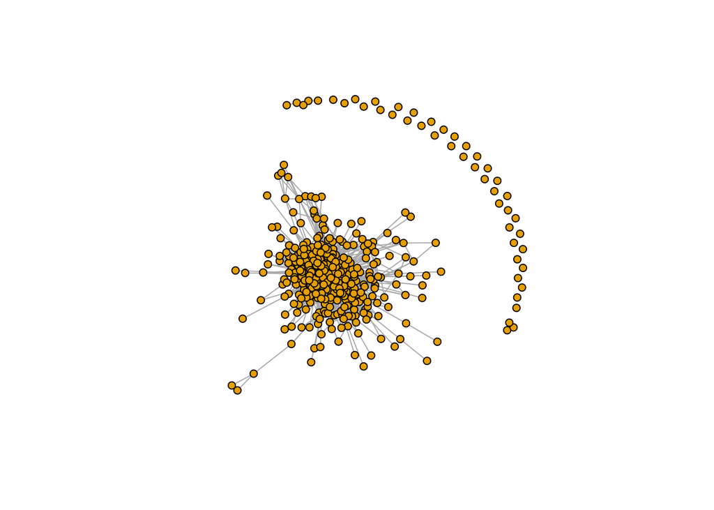

```r
userN= rates$user_id
rates = select(rates, -user_id)
rates = as.matrix(rates)
rownames(rates) = userN
r = as(rates, "realRatingMatrix")
similarity_books <- recommenderlab::similarity(r,  method = "cosine", which = "items")
comm=as.matrix(similarity_books)
comm=replace_na(comm,replace=1)
median_s = median(comm)
mean_s= mean(comm)
cm = ifelse(comm[ , ] <= mean_s, "1", "0")
com_nets <- graph_from_adjacency_matrix(adjmatrix = cm, mode = "undirected",diag = FALSE)
plot(com_nets, vertex.label=NA, vertex.size=5)
```

Присвоим вершинам данные из таблицы

```r
inorder = match(as.numeric(V(com_nets)$name),  goodread_comics$book_id)
books = goodread_comics[inorder,]
V(com_nets)$name=books$title
V(com_nets)$year=books$publication_year
V(com_nets)$pub=(books$publisher)
V(com_nets)$shelf=as.factor(books$popular_shelves.0.name)
V(com_nets)$rate=books$average_rating
```

Построим более информативный и визуально приятный график сети

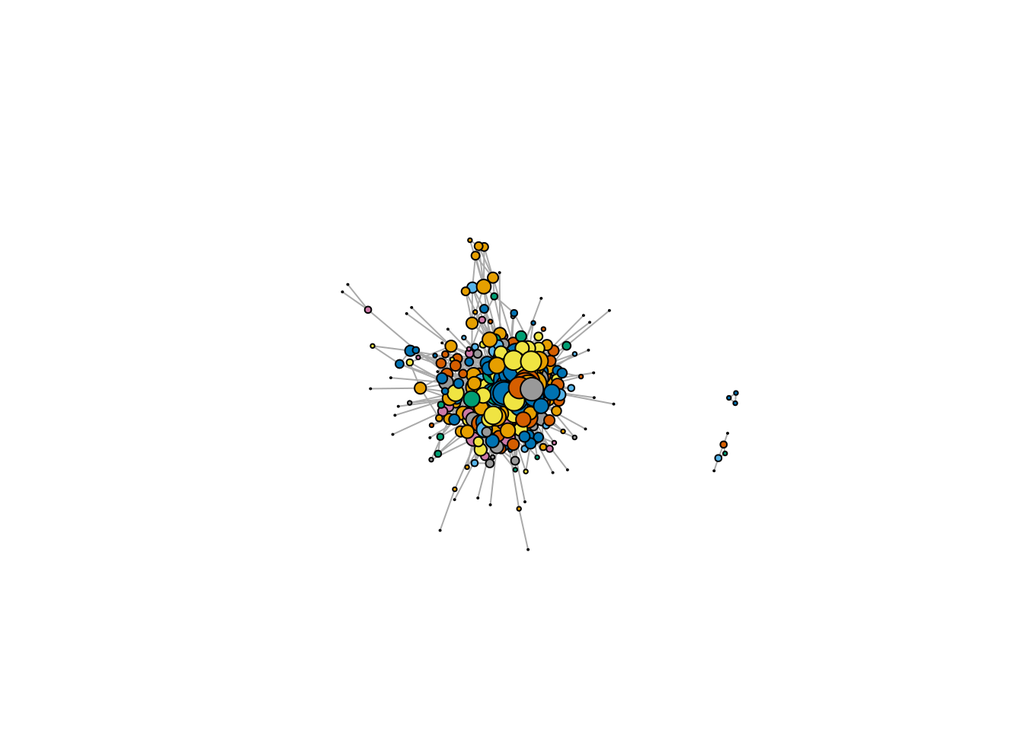

```r
plot(com_nets, vertex.size=(log(degree(com_nets))*3),vertex.color=as.factor(V(com_nets)$pub),vertex.frame.color = "black", vertex.label=NA)
```

Проверим зависимость сети от других переменных (издатель, полка, рейтинг, год издания соответственно):

```r
assortativity_nominal(com_nets, as.factor(V(com_nets)$pub), directed = F)
```

```
## [1] 0.07776424
```

```r
assortativity_nominal(com_nets, V(com_nets)$shelf, directed = F)
```

```
## [1] -0.0045594
```

```r
assortativity(com_nets, V(com_nets)$rate, directed = F)
```

```
## [1] 0.06401744
```

```r
assortativity_nominal(com_nets, as.factor(V(com_nets)$year), directed = F)
```

```
## [1] 0.02604498
```

Ассортативность очень мала, нельзя сказать, что определенные факторы сильно влияют на образование связей.

*Разделение на сообщества*

В этой части сетевого анализа была учтена рекомендация/замечание из peer review: *при разбиении на сообщества были проверены лишь методы walktrap и fastgreedy, и разбиение получилось не очень удачным (модулярность). возможно, стоило попробовать другие методы, и тогда результаты анализа можно было бы применить в дальнейшем*

В итоге были подсчитаны модульности дополнительных методов разбиений на сообщества, и действительно был найден более успешный метод (ранее был fastgreedy, а стал multilevel), но не намного. Модульность увеличилась всего на 0.02, что в корне не изменило результат сетевого анализа и не повлияло на дальнейшее построение рекомендаций.

Метод разбиения на сообщества spinglass не подходит для нашго графа, так как не все ноды связаны (unconnected graph)

Разделим сеть на сообщества и проверим модульность разбиения: всего 46 сообществ при более высоком значении modularity, но оно все равно слишком мало - 0,21.

```r
fgcommune <- fastgreedy.community(com_nets)

mcommune <- multilevel.community(com_nets)
wtcommune <- walktrap.community(com_nets)
infocommune <- cluster_infomap(com_nets, e.weights = NULL, v.weights = NULL,
  nb.trials = 10, modularity = TRUE)


modularity(fgcommune)
```

```
## [1] 0.1832046
```

```r
modularity(wtcommune)
```

```
## [1] 0.1227441
```

```r
modularity(mcommune)
```

```
## [1] 0.2118568
```

```r
modularity(infocommune)
```

```
## [1] 0.06001472
```

Модульность у mcommune, разделенное на сообщества методом multilevel, немного больше чем у fgcommune (но все равно довольно маленькая), а групп при этом одинаковое количество - 46, посмотрим на это распределение по сообществам на графе.

```r
mcommune
```

```
## IGRAPH clustering multi level, groups: 46, mod: 0.21
## + groups:
##   $`1`
##   [1] "Asterix in Corsica (Asterix, #20)"
##
##   $`2`
##   [1] "Asterix in Britain (Asterix, #8)"
##
##   $`3`
##   [1] "Battle Royale, Vol. 09 (Battle Royale, #9)"
##
##   $`4`
##   + ... omitted several groups/vertices
```

Визулизируем граф с подграфами сообществ: как мы можем заметить всего 6 сообществ охватывают наибольшее количество комиксов, а остальные 40 состоят из нескольких вершин (большинство из одной)

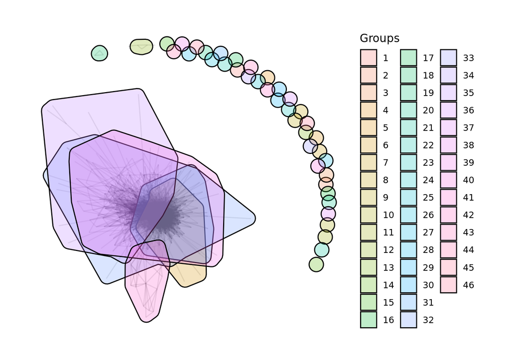

```r
com_nets %>%
as_tbl_graph() %>%
mutate(Groups = factor(membership(mcommune))) %>%
ggraph(layout = "nicely") +
geom_edge_link(alpha = 0.1) +
theme_graph()+
geom_mark_hull(
aes(x, y, group = Groups, fill = Groups),
concavity = 4,
expand = unit(2, "mm"),
alpha = 0.25
)
```

*Вывод*: Таким образом, построение сети по пользовательским оценкам и разбиение дает нам шесть больших сообществ и 40 более маленьких, которые могли бы оказаться полезными для рекомендаций, но модульность разбиения слишком мала, чтобы строить на данном разбиении качественную рекомендательную систему.

#### Добавление новых переменных

В ходе проекта было решено добавить новую переменную Series, с указанием серии комиксов (например, серия про Бэтмена). Эта переменная будет полезна при создании content-based рекомендательной системы.

```r
#Выделим серии книг. Обычно на серию указывают слова перед "Vol.", перед двоеточием или скобками. Вынесем названия серий в отдельную колонку.
#Выноси слова перед этми знаками и затем оставляем только нужное нам словосочетание

goodread_comics$series = str_extract(goodread_comics$title, "[:print:]+(?=\\, Vol?)")
goodread_comics$seriesTF = str_detect(goodread_comics$title, "[:print:]+(?=\\, Vol?)")
goodread_comics$punctTF = str_detect(goodread_comics$series, "[\\:\\(]")

goodread_comics$series2 = str_extract(goodread_comics$title, "[:print:]+(?=\\: ?)")
goodread_comics$seriesTF2 = str_detect(goodread_comics$title, "[:print:]+(?=\\: ?)")
goodread_comics$punctTF2 = str_detect(goodread_comics$series2, "[\\:\\(]")

goodread_comics$series3 = str_extract(goodread_comics$title, "[:print:]+(?=\\([A-z]?)")
goodread_comics$seriesTF3 = str_detect(goodread_comics$title, "[:print:]+(?=\\([A-z]?)")

goodread_comics$punctTF3 = str_detect(goodread_comics$series3, "[\\:\\(]")

goodread_comics$Series = case_when(goodread_comics$seriesTF == TRUE & goodread_comics$punctTF == FALSE ~ goodread_comics$series,
goodread_comics$seriesTF2 == TRUE & goodread_comics$punctTF2 == FALSE ~ goodread_comics$series2,
goodread_comics$seriesTF3 == TRUE & goodread_comics$punctTF3 == FALSE ~ goodread_comics$series3,
TRUE ~ goodread_comics$title)

goodread_comics = goodread_comics %>% select(-series, - series2, -series3, -seriesTF, -punctTF, -seriesTF2, - seriesTF3, -punctTF2, -punctTF3)
```

### Коллаборативная фильтрация

Для того, чтобы разработать рекомендательную систему с помощью метода коллаборативной фильтрации, нам нужно создать таблицу, в которой останутся только оценки пользователей для фильмов, никаких лишних характеристик. Для этого отдельно сохраним имена пользователей и уберем user_id из данных.

```r
cfcomics = goodread_reviews%>% select(book_id,user_id,rating)
cfrates = pivot_wider(cfcomics, names_from = book_id , values_from = rating)

userNames = cfrates$user_id
cfrates = select(cfrates, -user_id)
```

Далее преобразуем данные к удобному для работы формату.

```r
library(recommenderlab)

# преобразование таблицы данных в матрицу
cfrates = as.matrix(cfrates)
rownames(cfrates) = userNames
# преобразование матрицы в realRatingMatrix
cf = as(cfrates, "realRatingMatrix")
```

Рассмотрим распределение количества оценок к каждому фильму и распределение количества оценок, которые поставил каждый пользователь.

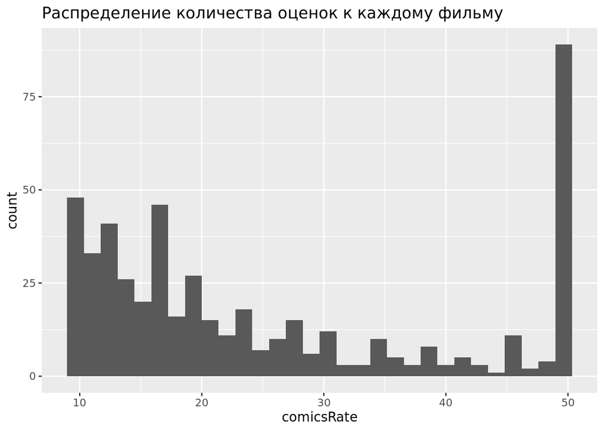

```r
ggplot(data = data.frame(comicsRate=colCounts(cf))) + geom_histogram(aes(x=comicsRate))+
  ggtitle("Распределение количества оценок к каждому фильму")
```

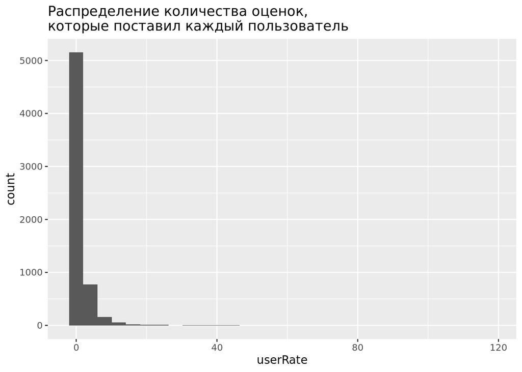

```r
ggplot(data = data.frame(userRate=rowCounts(cf))) + geom_histogram(aes(x=userRate))+
  ggtitle("Распределение количества оценок, \nкоторые поставил каждый пользователь")
```

Далее убираем нерелевантные данные, то есть то, что нельзя проанализировать (пользователей, которые оценили слишком мало комиксов, а также комиксы с маленьким количеством оценок). Для этого удалим пользователей, которые оставили меньше пяти отзывов, а также комиксы с количеством оценок меньше 10.

```r
cfratings_comics <- cf[rowCounts(cf) > 5, colCounts(cf) > 10]
```

Строим рекомендательную модель: делим на тестовую и обучающую выборки, используем метод IBCF. В итоге получаем систему, которая каждому пользователю рекомендует 5 комиксов, которые могли бы быть ему интересны на основе его отзывов.

```r
set.seed(100)
cftest_ind <- sample(1:nrow(cfratings_comics), size = nrow(cfratings_comics)*0.2)
cfrecc_data_train <- cfratings_comics[-cftest_ind, ]
cfrecc_data_test <- cfratings_comics[cftest_ind, ]

cfrecc_model <- Recommender(data = cfrecc_data_train, method = "IBCF")

cfreccom <- predict(object = cfrecc_model, newdata = cfrecc_data_test, n = 5)
```

Далее рассмотрим процесс поиска комиксов для пользователя 71952337fe8e1594f431a674dcb73e7e.

```r
cfrecc_user_1 <- cfreccom@items[["71952337fe8e1594f431a674dcb73e7e"]]
cfcomics_user_1 <- cfreccom@itemLabels[cfrecc_user_1]
cf_names_comics_user <- goodread_comics$title[match(cfcomics_user_1, goodread_comics$book_id)]
cf_names_comics_user
```

```
## [1] "Green Arrow, Vol. 1: Quiver"
## [2] "Fables, Vol. 7: Arabian Nights [and Days] (Fables, #7)"
## [3] "Arkham Asylum: Living Hell"
## [4] "Astro City, Vol. 3: Family Album"
## [5] "The Dragonslayer (Bone, #4)"
```

Построим функцию, которая автоматически будет выдавать на имя пользователя рекомендации по комиксам. Тем пользователям, которых мы отсеяли ранее из-за нерелевантности, будет выводиться в результате 5 комиксов с самыми высокими средними оценками.

```r
cfgetComics= function(User_id){
  cfcomics = goodread_reviews%>% select(book_id,user_id,rating)
cfrates = pivot_wider(cfcomics, names_from = book_id , values_from = rating)
userNames = cfrates$user_id
cfrates = select(cfrates, -user_id)
library(recommenderlab)
cfrates = as.matrix(cfrates)
rownames(cfrates) = userNames
cf = as(cfrates, "realRatingMatrix")
cfratings_comics <- cf[rowCounts(cf) > 5, colCounts(cf) > 10]
set.seed(100)
cftest_ind <- sample(1:nrow(cfratings_comics), size = nrow(cfratings_comics)*0.2)
cfrecc_data_train <- cfratings_comics[-cftest_ind, ]
cfrecc_data_test <- cfratings_comics[cftest_ind, ]
cfrecc_model <- Recommender(data = cfrecc_data_train, method = "IBCF")
cfreccom <- predict(object = cfrecc_model, newdata = cfrecc_data_test, n = 5)
x=User_id
cfrecc_user_1 <- cfreccom@items[[x]]
cfcomics_user_1 <- cfreccom@itemLabels[cfrecc_user_1]
cf_names_comics_user <- goodread_comics$title[match(cfcomics_user_1, goodread_comics$book_id)]
#узнаем из этой функции самые популярные комиксы для рекомендации новымпользователям или тем, кто оценил слишком мало комиксов
cfbestcomics=arrange(goodread_comics, desc(average_rating))

if(identical(cf_names_comics_user, character(0))){
print("The Walking Dead, Compendium 3")
print("Fullmetal Alchemist, Vol. 19 (Fullmetal Alchemist, #19)")
print("Skip Beat!, Vol. 26")
print("Fullmetal Alchemist, Vol. 12 (Fullmetal Alchemist, #12)")
print("Skip Beat!, Vol. 16")
} else {cf_names_comics_user}}
```

**Оценивание рекомендации:**

# Оцениваем систему, где входные данные - это случайно выбранный пользователь

Начнем проверку все с того же пользователя - “71952337fe8e1594f431a674dcb73e7e”

```r
cfgetComics("71952337fe8e1594f431a674dcb73e7e")
```

```
## [1] "Green Arrow, Vol. 1: Quiver"
## [2] "Fables, Vol. 7: Arabian Nights [and Days] (Fables, #7)"
## [3] "Arkham Asylum: Living Hell"
## [4] "Astro City, Vol. 3: Family Album"
## [5] "The Dragonslayer (Bone, #4)"
```

```r
evaladeq = goodread_comics %>% select(title, popular_shelves.3.name,book_id, is_ebook, num_pages)
adeqlevel = filter(goodread_reviews, user_id == "71952337fe8e1594f431a674dcb73e7e") %>%
  top_n(5, rating)
evaladeq = inner_join(evaladeq,adeqlevel, by = c("book_id" = "book_id")) %>% select(title, popular_shelves.3.name, is_ebook, num_pages)
evaladeq
```

```
##                                             title popular_shelves.3.name
## 1:              ODY-C, Vol. 1: Off to Far Ithicaa          graphic-novel
## 2: Runaways, Vol. 1: Pride and Joy (Runaways, #1)          graphic-novel
## 3:                      The Guild (The Guild, #1)          graphic-novel
## 4:                       Batman: The Black Mirror                     dc
## 5:               The Eternal Smile: Three Stories                 comics
##    is_ebook num_pages
## 1:    false       136
## 2:    false       144
## 3:    false        79
## 4:    false       288
## 5:    false       170
```

```r
rec1 = goodread_comics %>% select(title, popular_shelves.3.name, book_id, is_ebook, num_pages) %>% filter(title== "Green Arrow, Vol. 1: Quiver", )
rec2 = goodread_comics %>% select(title, popular_shelves.3.name, book_id, is_ebook, num_pages) %>% filter(title== "Fables, Vol. 7: Arabian Nights [and Days] (Fables, #7)")
rec3 = goodread_comics %>% select(title, popular_shelves.3.name, book_id, is_ebook, num_pages) %>% filter(title== "Arkham Asylum: Living Hell")
rec4 = goodread_comics %>% select(title, popular_shelves.3.name, book_id, is_ebook, num_pages) %>% filter(title== "Astro City, Vol. 3: Family Album")
rec5 = goodread_comics %>% select(title, popular_shelves.3.name, book_id, is_ebook, num_pages) %>% filter(title== "The Dragonslayer (Bone, #4)")


#Таким образом мы видим, что данному пользователю система порекомендовала следующие комиксы:
# 1) "Green Arrow, Vol. 1: Quiver"
# 2) "Fables, Vol. 7: Arabian Nights [and Days] (Fables, #7)"
# 3) "Arkham Asylum: Living Hell"
# 4) "Astro City, Vol. 3: Family Album"
# 5) "The Dragonslayer (Bone, #4)"

# В то же время даному пользователю нравятся следующие комиксы:
# 1) ODY-C, Vol. 1: Off to Far Ithicaa
# 2) Runaways, Vol. 1: Pride and Joy (Runaways, #1)
# 3) The Guild (The Guild, #1)
# 4) Batman: The Black Mirror
# 5) The Eternal Smile: Three Stories

#Наша рекомендательная система не подобрала идентичные комиксы нашему пользователю, тем не менее, мы видим, что система порекомендовала жанр графические новеллы, которые как раз таки нравятся нашему пользователю, более того, здесь даже присутствует общая серия комиксов про бэтмена - "Arkham Asylum: Living Hell" в рекомендации и Batman: The Black Mirror в категории любимых комиксов у пользователя, что доказывает верную работу рекомендательной системы. Также можно заметить, что такие параметры как "является электронной книгой" и " количество страниц" также схожи, с преобладанием  неэлектронных книг, и средней продолжительность книги около 150 страниц.
```

```r
cfgetComics("c05512c006dd9ccb49b147ce619621d5")
```

```
## [1] "Zatanna, Vol. 2: Shades of the Past"
## [2] "Re*pro*duct Volume 1: Reproduct"
## [3] "Rat Queens: Deluxe Edition, Volume 1"
## [4] "Runaways, Vol. 1: Pride and Joy (Runaways, #1)"
## [5] "Return to Labyrinth, Vol. 1"
```

```r
evaladeq1 = goodread_comics %>% select(title, popular_shelves.3.name, book_id, is_ebook, num_pages)
adeqlevel1 = filter(goodread_reviews, user_id == "c05512c006dd9ccb49b147ce619621d5") %>%
  top_n(5, rating)
evaladeq1 = inner_join(evaladeq1, adeqlevel1, by = c("book_id" = "book_id")) %>% select(title, popular_shelves.3.name, is_ebook, num_pages)
evaladeq1
```

```
##                                                             title
##  1:                 A Bride's Story, Vol. 3 (A Bride's Story, #3)
##  2:                                      Victory (Resistance, #3)
##  3:                                            The Sandwich Thief
##  4:                     Southern Bastards, Vol. 1: Here Was a Man
##  5:                                              Providence Act 2
##  6:                 Fatale, Book Four: Pray for Rain (Fatale, #4)
##  7:                                      Harvey Pekar's Cleveland
##  8:                     The Diary of Edward the Hamster 1990–1990
##  9:                                   James Bond, Vol. 2: Eidolon
## 10:                                           Everywhere Antennas
## 11:                                                          Pixu
## 12: Moon Knight, Volume 1: From the Dead (Moon Knight Vol. V, #1)
## 13:                                              Preacher, Book 3
## 14:                                              Preacher, Book 6
```

[output cut: 23 more lines]

```r
r1 = goodread_comics %>% select(title, popular_shelves.3.name, book_id, is_ebook, num_pages) %>% filter(title== "Zatanna, Vol. 2: Shades of the Past", )
r2 = goodread_comics %>% select(title, popular_shelves.3.name, book_id, is_ebook, num_pages) %>% filter(title== "Re*pro*duct Volume 1: Reproduct")
r3 = goodread_comics %>% select(title, popular_shelves.3.name, book_id, is_ebook, num_pages) %>% filter(title== "Rat Queens: Deluxe Edition, Volume 1")
r4 = goodread_comics %>% select(title, popular_shelves.3.name, book_id, is_ebook, num_pages) %>% filter(title== "Runaways, Vol. 1: Pride and Joy (Runaways, #1)" )
r5 = goodread_comics %>% select(title, popular_shelves.3.name, book_id, is_ebook, num_pages) %>% filter(title== "Return to Labyrinth, Vol. 1")


#Таким образом мы видим, что данному пользователю система порекомендовала следующие комиксы:
# 1) "Zatanna, Vol. 2: Shades of the Past"
# 2) "Re*pro*duct Volume 1: Reproduct"
# 3) "Rat Queens: Deluxe Edition, Volume 1"
# 4) "Runaways, Vol. 1: Pride and Joy (Runaways, #1)"
# 5) "Return to Labyrinth, Vol. 1"

# В то же время даному пользователю нравятся следующие комиксы:
# 1) A Bride's Story, Vol. 3 (A Bride's Story, #3)
# 2) Southern Bastards, Vol. 1: Here Was a Man
# 3) Preacher, Book 6
# 4) Everywhere Antennas
# 5) Moon Knight, Volume 1: From the Dead (Moon Knight Vol. V, #1)
# и другие

# Таким образом, можно увидеть, что рекомендательная система идеально подобрала рекомендации нашему пользователю по жанру (graphic-novels), ведь большинство комиксов, которые нравятся нашему пользователю (в отзывах которых преобладают оценки 4 и 5) обладают именно этим жанром. Кроме того, данный пользователь также не любит электронные книги, но предпочитает книги c довольно большой длительностью (превышающей 100 страниц), что и прорекомендовала ему наша система.
```

### Content-based рекомендация

Для создания content-based рекомендательной системы будут использоваться следующие переменные: * num_pages – количество страниц (кому-то важен размер комикса) * publication_year – год публикации * ratings_count – количество отзывов на goodreads на момент сбора данных * authors.0.author_id – id первого автора (пользователям могут нравятся определенные авторы) * publisher – издатель (кто-то может любить комиксы определенного издательства, т.к. последнее обычно издает примерно похожие комиксы) * Series – серия книг (например, кому-то может понравится комикс про Бэтмена)

Построим функцию, в которую нужно обязательно вписать id пользователя, а также можно задать количество комиксов, которые будут порекомендованы. Работает она следующим образом: - Изначально функция ищет комиксы, которые похожи на те, что пользователь оценил на 5. - Если нет комиксов, оцененных на 5, то ищутся комиксы, оцененные на 4, а так же к ним добавляются комиксы с самым высоким средним рейтингом (одна пятая от рекомендованных комиксов), чтобы он мог попробовать найти новые комиксы, которые ему больше понравятся. - Если пользователь не оценил ни одного комикса на 5 или на 4 или если пользователь новый, то ему/ей будут предложены только комиксы с самым высоким средним рейтингом. Название комиксов, упорядочивается по показателю схожести, в случае, где показываются еще и популярные комиксы, сначала идут рекомендации на основе понравившихся комиксов, а потом популярные.

```r
# предварительный код

#Оставляем только нужные переменные
goodread_comics_new = goodread_comics %>% dplyr::select(book_id, authors.0.author_id, num_pages, publication_year, publisher, ratings_count, Series)

#Считаем среднюю оценку фильма по отзывам "наших" пользователей
data_mean = goodread_reviews %>% group_by(book_id) %>% summarize(rating = mean(rating))
#Объединяем датасеты
data = inner_join(data_mean, goodread_comics_new)

#Считаем матрицу схожести фильмов, перед этим немного преобразовывая переменные и переводим id в названия строк, т.к. мы не хотим, чтобы разница в id влияла на схожесть фильмов

#преобразуем текстовые переменные в такой формат, чтобы посмотреть похожесть
data$ratings_count = as.numeric(data$ratings_count)
data$rating = as.numeric(data$rating)
data$num_pages = as.numeric(data$num_pages)
data$publication_year = as.numeric(data$publication_year)
data$authors.0.author_id = as.factor(data$authors.0.author_id)
data$odin = 1

#преобразуем нечисловые переменные
#автор
wider = data %>% select(book_id, authors.0.author_id, odin)
wider = pivot_wider(wider, names_from = authors.0.author_id, values_from = odin, values_fill = 0)
data = left_join(data, wider)

#издатель
wider = data %>% select(book_id, publisher, odin)
# у некоторых комиксов нет издателя, удалим их из обоих датасетов
wider = wider %>% mutate(value = str_detect(publisher, "[:alpha:]"))
wider$publisher = case_when(wider$value == TRUE ~ wider$publisher, wider$value == FALSE ~ "not_stated")
wider = wider %>% select(-value)
wider$publisher = str_replace(wider$publisher, "Marvel Comics", "Marvel")
wider = pivot_wider(wider, names_from = publisher, values_from = odin, values_fill = 0)
wider = wider %>% select(-not_stated)
data = inner_join(data, wider)

wider = data %>% select(book_id, Series, odin)
wider = pivot_wider(wider, names_from = Series, values_from = odin, values_fill = 0)
data = left_join(data, wider)

#min(data$publication_year %>% na.omit()) #1991
#max(data$publication_year %>% na.omit()) #2017
#сделаем разделение по пятилетиям, в последнюю пятилетку добавиви еще 2 года
wider = data %>% select(book_id, publication_year, odin)
wider$publication_year = replace_na(wider$publication_year, 9999)
wider$year = case_when((wider$publication_year >= 1991 & wider$publication_year <= 1995) == T ~ "year1", (wider$publication_year >= 1991 & wider$publication_year <= 1995) == T ~ "year2", (wider$publication_year >= 1996 & wider$publication_year <= 2000) == T ~ "year3", (wider$publication_year >= 2001 & wider$publication_year <= 2005) == T ~ "year4", (wider$publication_year >= 2006 & wider$publication_year <= 2010) == T ~ "year5", (wider$publication_year >= 2011 & wider$publication_year <= 2017) == T ~ "year6", wider$publication_year == 9999 ~ "not_stated")
wider = wider %>% select(book_id, year, odin)
wider = pivot_wider(wider, names_from = year, values_from = odin, values_fill = 0)
wider = wider %>% select(-not_stated)
data = left_join(data, wider)


#min(data$num_pages %>% na.omit()) #13
#max(data$num_pages %>% na.omit()) #1088
#сделаем категории
wider = data %>% select(book_id, num_pages, odin)
wider$num_pages = replace_na(wider$num_pages, 9999)
wider$pages = case_when((wider$num_pages >= 0 & wider$num_pages <= 200) == T ~ "pages1", (wider$num_pages >= 201 & wider$num_pages <= 400) == T ~ "pages2", (wider$num_pages >= 401 & wider$num_pages <= 600) == T ~ "pages3", (wider$num_pages >= 601 & wider$num_pages <= 800) == T ~ "pages4", (wider$num_pages >= 801 & wider$num_pages <= 1088) == T ~ "pages5", wider$num_pages == 9999 ~ "not_stated")
wider = wider %>% select(book_id, pages, odin)
wider = pivot_wider(wider, names_from = pages, values_from = odin, values_fill = 0)
wider = wider %>% select(-not_stated)
data = left_join(data, wider)

#min(data$ratings_count) #30
#max(data$ratings_count) #77308
#сделаем категории
wider = data %>% select(book_id, ratings_count, odin)
wider$rating = case_when((wider$ratings_count >= 0 & wider$ratings_count <= 1000) == T ~ "rating1", (wider$ratings_count >= 1001 & wider$ratings_count <= 5000) == T ~ "rating2", (wider$ratings_count >= 5001 & wider$ratings_count <= 10000) == T ~ "rating3", (wider$ratings_count >= 10000 & wider$ratings_count <= 20000) == T ~ "rating4", (wider$ratings_count >= 20001 & wider$ratings_count <= 40000) == T ~ "rating5", (wider$ratings_count >= 40001 & wider$ratings_count <= 50000) == T ~ "rating6", (wider$ratings_count >= 50001 & wider$ratings_count <= 80000) == T ~ "rating7")
wider = wider %>% select(book_id, rating, odin)
wider = pivot_wider(wider, names_from = rating, values_from = odin, values_fill = 0)
data = left_join(data, wider)

#удалим ненужные переменные
data = data %>% select(-authors.0.author_id, - publisher, -Series, -publication_year, -ratings_count, -num_pages, -odin)

rownames = data$book_id
data = data %>% dplyr::select(-book_id)
rownames(data) = rownames

data = t(as.matrix(data))
sim = lsa::cosine(data)
diag(sim) = 0 #зануляем главную диагональ
```

```r
# функция для рекомендации CB
getComics_user = function(User_id, num = 5){#по умолчанию 5 фильмов
  user = goodread_reviews %>% filter(user_id == User_id & rating == 5)
  Meanrating = goodread_reviews %>% group_by(book_id) %>% summarise(meanr = mean(rating)) %>% arrange(-meanr)

  if (nrow(user)==0) {
    user1 = goodread_reviews %>% filter(user_id == User_id & rating == 4)

    if (nrow(user1)==0) {
      NumFilm = Meanrating[1:num,]
      result = NumFilm$book_id
      recommend = inner_join(goodread_comics, NumFilm) %>% arrange(-meanr) %>% dplyr::select(title)
    } else {
      pred = num*0.8
      pred = pred %>% round(0)
      sug = num*0.2
      sug = sug %>% round(0)

      mostSimilar = head(sort(sim[,as.character(user1$book_id[1])], decreasing = T), n = pred)
      Most_similar = data.frame(mostSimilar)
      Most_similar$book_id = rownames(Most_similar)
      Most_similar$book_id = as.numeric(Most_similar$book_id)
      recommend1 = inner_join(goodread_comics, Most_similar) %>% arrange(mostSimilar) %>% dplyr::select(title)

      NumFilm = Meanrating[1:sug,]
      recommend2 = inner_join(goodread_comics, NumFilm) %>% arrange(-meanr) %>% dplyr::select(title)

      recommend = rbind(recommend1, recommend2)
    }
  } else {
    mostSimilar = head(sort(sim[,as.character(user$book_id[1])], decreasing = T), n = num)
    Most_similar = data.frame(mostSimilar)
    Most_similar$book_id = rownames(Most_similar)
    Most_similar$book_id = as.numeric(Most_similar$book_id)
    recommend = inner_join(goodread_comics, Most_similar) %>% arrange(mostSimilar) %>% dplyr::select(title)
  }

  recommend
}
```

Сделаем также Content-based рекомендательную систему с вводом названия комикса как исходные данные. Также как и в предыдущей рекомендательной системе, можно задать количество комиксов, которые будут порекомендованы. Пользователь может указать неполное название, тогда функция подберет рекомендации для первого комикса, у которого в названии есть такие же символы.

```r
getComics_comics = function(Comics_name, num = 10){
#по умолчанию 5 фильмов
Comics_name = str_to_lower(Comics_name)
goodread_comics$title_new = str_to_lower(goodread_comics$title)
Comics_id = goodread_comics[title_new == Comics_name, "book_id"]
if (nrow(Comics_id) == 0) {
  Comics_name = str_remove_all(Comics_name, "[:digit:]")
  Comics_name = str_remove_all(Comics_name, "[:punct:]")
  goodread_comics$Name = str_detect(goodread_comics$title_new, Comics_name)
  Comics_id = goodread_comics %>% filter(Name == TRUE) %>% select("book_id")
  Comics_id = Comics_id[1,1]
  mostSimilar = head(sort(sim[, as.character(Comics_id)], decreasing = T), n = num)
  Most_similar = data.frame(mostSimilar)
  Most_similar$book_id = rownames(Most_similar)
  Most_similar$book_id = as.numeric(Most_similar$book_id)
  recommend = inner_join(goodread_comics, Most_similar) %>% arrange(mostSimilar) %>% dplyr::select(title)
  recommend
} else {
  mostSimilar = head(sort(sim[, as.character(Comics_id)], decreasing = T), n = num)
  Most_similar = data.frame(mostSimilar)
  Most_similar$book_id = rownames(Most_similar)
  Most_similar$book_id = as.numeric(Most_similar$book_id)
  recommend = inner_join(goodread_comics, Most_similar) %>% arrange(mostSimilar) %>% dplyr::select(title)
  recommend
}
}
```

**Оценивание рекомендации: Внутренняя пользовательская оценка**

### Примеры

##### Примеры collaborative filtering

Проверим получившуюся систему на пользователе “71952337fe8e1594f431a674dcb73e7e”, результат получается верный.

```r
cfgetComics("71952337fe8e1594f431a674dcb73e7e")
```

```
## [1] "Green Arrow, Vol. 1: Quiver"
## [2] "Fables, Vol. 7: Arabian Nights [and Days] (Fables, #7)"
## [3] "Arkham Asylum: Living Hell"
## [4] "Astro City, Vol. 3: Family Album"
## [5] "The Dragonslayer (Bone, #4)"
```

Чтобы доказать, что результат не случайный, проверим для ещё одного пользователя.

```r
cfgetComics("c05512c006dd9ccb49b147ce619621d5")
```

```
## [1] "Zatanna, Vol. 2: Shades of the Past"
## [2] "Re*pro*duct Volume 1: Reproduct"
## [3] "Rat Queens: Deluxe Edition, Volume 1"
## [4] "Runaways, Vol. 1: Pride and Joy (Runaways, #1)"
## [5] "Return to Labyrinth, Vol. 1"
```

Также проверим систему для нового пользователя или для пользователя, который оценил слишком мало фильмов. В результате получаем 5 комиксов с самыми высокими оценками.

```r
cfgetComics("new")
```

```
## [1] "The Walking Dead, Compendium 3"
## [1] "Fullmetal Alchemist, Vol. 19 (Fullmetal Alchemist, #19)"
## [1] "Skip Beat!, Vol. 26"
## [1] "Fullmetal Alchemist, Vol. 12 (Fullmetal Alchemist, #12)"
## [1] "Skip Beat!, Vol. 16"
```

##### Примеры content-based

###### Content-based рекомендация по пользователю

Рассмотрим, как функция справляется с различными сценариями, учтенными при ее создании:

1. на пользователях, у которых есть оценки 5
- пользователь 7ca8aa37069f3c051b2d067ea9efbe65

```r
getComics_user("7ca8aa37069f3c051b2d067ea9efbe65")
```

```
##                                                  title
## 1:               The Punisher MAX, Vol. 5: The Slavers
## 2:                 Deadpool, Volume 4: Monkey Business
## 3:                            Wolverine: Old Man Logan
## 4:                                X-23: Innocence Lost
## 5: Runaways, Vol. 2:  Teenage Wasteland (Runaways, #2)
```

- пользователь d6d7ac93d1f824ab02f74851d173c4e8

```r
getComics_user("d6d7ac93d1f824ab02f74851d173c4e8")
```

```
##                                                            title
## 1:                 The Walking Dead, Vol. 03: Safety Behind Bars
## 2:               Death Note, Vol. 2: Confluence (Death Note, #2)
## 3:                                   James Bond, Vol. 2: Eidolon
## 4:                                       All My Friends Are Dead
## 5: Transmetropolitan, Vol. 6: Gouge Away (Transmetropolitan, #6)
```

2. на пользователях, у которых нет оценки 5, но есть оценки 4
- пользователь ab2fadb5c7bbe55c80406d2b3692e969

```r
getComics_user("ab2fadb5c7bbe55c80406d2b3692e969")
```

```
##                                                  title
## 1:                 Deadpool, Volume 4: Monkey Business
## 2:                            Wolverine: Old Man Logan
## 3:                                X-23: Innocence Lost
## 4: Runaways, Vol. 2:  Teenage Wasteland (Runaways, #2)
## 5:                                      Invader Zim #1
```

- пользователь 00125c81ba9ef0504bd02697fdbc3827

```r
getComics_user("00125c81ba9ef0504bd02697fdbc3827")
```

```
##                              title
## 1:  Superman: For Tomorrow, Vol. 2
## 2:             Batman: False Faces
## 3:                    Batman: Snow
## 4: Wonder Woman, Vol. 7: Contagion
## 5:                  Invader Zim #1
```

3. на пользователях, у которых нет ни 4, ни 5
- пользователь 2ff3b7ca5fca074482e30fd5fa85496b

```r
getComics_user("2ff3b7ca5fca074482e30fd5fa85496b")
```

```
##                                                                        title
## 1:                                                            Invader Zim #1
## 2:                                                The Walking Dead, Issue #4
## 3: 僕のヒーローアカデミア 5 [Boku No Hero Academia 5] (My Hero Academia, #5)
## 4:                                         Locke & Key, Volume 5: Clockworks
## 5:                                         Watashitachi no Shiawase na Jikan
```

- пользователь 002a023d3de233b4bd3ec4fc3e9c581a

```r
getComics_user("002a023d3de233b4bd3ec4fc3e9c581a")
```

```
##                                                                        title
## 1:                                                            Invader Zim #1
## 2:                                                The Walking Dead, Issue #4
## 3: 僕のヒーローアカデミア 5 [Boku No Hero Academia 5] (My Hero Academia, #5)
## 4:                                         Locke & Key, Volume 5: Clockworks
## 5:                                         Watashitachi no Shiawase na Jikan
```

4. и на пользователях, которых нет в системе
- пользователь 35ab

```r
getComics_user("35ab")
```

```
##                                                                        title
## 1:                                                            Invader Zim #1
## 2:                                                The Walking Dead, Issue #4
## 3: 僕のヒーローアカデミア 5 [Boku No Hero Academia 5] (My Hero Academia, #5)
## 4:                                         Locke & Key, Volume 5: Clockworks
## 5:                                         Watashitachi no Shiawase na Jikan
```

- пользователь abcd

```r
getComics_user("abcd")
```

```
##                                                                        title
## 1:                                                            Invader Zim #1
## 2:                                                The Walking Dead, Issue #4
## 3: 僕のヒーローアカデミア 5 [Boku No Hero Academia 5] (My Hero Academia, #5)
## 4:                                         Locke & Key, Volume 5: Clockworks
## 5:                                         Watashitachi no Shiawase na Jikan
```

Рассмотрим предложенные в peer-review примеры:

1. Будет ли порекомендован комикс про Супермена пользователю, который увлекается комиксами про Бетмена? Результат: комикс про Супермена может быть порекомендован, так как оба комикса относятся к супергеройской тематике

Найдем пользователя, который больше всех хорошо оценил комиксы про Бетмена (на 5 или на 4)

```r
goodread_comics_Batman = goodread_comics
goodread_comics_Batman$Batman = str_detect(goodread_comics_Batman$title, "Batman")
goodread_comics_Batman = goodread_comics_Batman %>% filter(goodread_comics_Batman$Batman == TRUE)
goodread_comics_Batman = goodread_comics_Batman %>% select(book_id)
goodread_reviews_Batman = goodread_reviews %>% filter(book_id %in% goodread_comics_Batman$book_id)

#возьмем пользователя, который оценил комиксы про Бетмена на 5 или на 4
goodread_reviews_Batman = goodread_reviews_Batman %>% filter(rating >= 4)
goodread_reviews_Batman %>% group_by(user_id) %>% count() %>% arrange(-n)
```

```
## # A tibble: 303 x 2
## # Groups:   user_id [303]
##    user_id                              n
##    <chr>                            <int>
##  1 ce0996178c46d462b9321725e94551c9     6
##  2 85b04c6415a88bdc0a48da3df74767b2     5
##  3 1d02d7115117999be6c86a54360c673b     3
##  4 26538f0f360954a65d7ef0dff0624a96     3
##  5 3b03b0e3350e312351cb0c5e7899a1f0     3
##  6 4a8b6f4c6a692e6eea5ac097978fee32     3
##  7 700124273584286345b341fb6308a144     3
##  8 8c1c357c3d46bf3dcf7051ba98559c7d     3
##  9 bdac9a558000de456a0be04663fa7676     3
## 10 049eb9773dbcd526aa6218fb25bcb0d2     2
## # … with 293 more rows
```

Возьмем пользователя ce0996178c46d462b9321725e94551c9, который оценил 6 комиксов про Бетмена на 4 и 5

```r
getComics_user("ce0996178c46d462b9321725e94551c9")
```

```
##                                      title
## 1:                         Lumberjanes #14
## 2: Barefoot Gen, Volume Two: The Day After
## 3:                                 Saga #5
## 4:                                 Saga #9
## 5:                                Saga #15
```

Комиксов про Супермена не выдано, потому что первый оцененный на 5 комикс в датасете не про Бэтмена.

2. Проверку на пользователе, которому нравятся несупергеройские комиксы, значит ему такие и должны рекомендоваться

Допустим Tokyo Guru (22447402) не про супергероев.

Найдем пользователя, который больше всех хорошо оценил комикс Tokyo Guru (на 5 или на 4)

```r
goodread_reviews_Tokyo = goodread_reviews %>% filter(book_id == 22447402)

#возьмем пользователя, который оценил комикс Tokyo Guru на 5 или на 4
goodread_reviews_Tokyo = goodread_reviews_Tokyo %>% filter(rating >= 4)
goodread_reviews_Tokyo %>% group_by(user_id) %>% count() %>% arrange(-n)
```

```
## # A tibble: 29 x 2
## # Groups:   user_id [29]
##    user_id                              n
##    <chr>                            <int>
##  1 0d646366ef0d0f351fecf0fb4ef6c081     1
##  2 11117f92e93bb2ffa6a26f7e991e2a26     1
##  3 14834b1828124ed2ac0045d66f22f0fa     1
##  4 330d5e764ea628140a368502f7d342f1     1
##  5 3c567735f549e5329c894815515b797a     1
##  6 3e146bd5bd01924b67926305fdcf5691     1
##  7 6396585a07ff5c65559b7558b167d251     1
##  8 817ae71dc02e8ab9cd8ebc8cdbe6535a     1
##  9 82266030911da4063c8bb8ece17f0f80     1
## 10 8470526198620b8d4f8ae2f1cf1a79cb     1
## # … with 19 more rows
```

Возьмем пользователя 0d646366ef0d0f351fecf0fb4ef6c081, который оценил его на 5.

```r
getComics_user("0d646366ef0d0f351fecf0fb4ef6c081")
```

```
##                                                                        title
## 1:                    The Walking Dead: Days Gone Bye (The Walking Dead, #1)
## 2:                                                       Skip Beat!, Vol. 26
## 3:                                      Becoming (Otherworld Stories, #0.09)
## 4: 僕のヒーローアカデミア 5 [Boku No Hero Academia 5] (My Hero Academia, #5)
## 5:               東京喰種トーキョーグール 5 [Tokyo Guru 5] (Tokyo Ghoul, #5)
```

Насколько нам известно, эти комиксы не про супергероев по типу Marvel.

3. Если пользователю нравятся комиксы с полки fantasy, какие комиксы ему порекомендуют?

Найдем пользователя, который больше всех хорошо оценил комиксы fantasy (на 5 или на 4)

```r
goodread_comics_Fantasy = goodread_comics
goodread_comics_Fantasy$Fantasy = str_detect(goodread_comics_Fantasy$popular_shelves.3.name, "fantasy")
goodread_comics_Fantasy = goodread_comics_Fantasy %>% filter(goodread_comics_Fantasy$Fantasy == TRUE)
goodread_comics_Fantasy = goodread_comics_Fantasy %>% select(book_id)
goodread_reviews_Fantasy = goodread_reviews %>% filter(book_id %in% goodread_comics_Fantasy$book_id)

#возьмем пользователя, который оценил комиксы fantasy на 5
goodread_reviews_Fantasy = goodread_reviews_Fantasy %>% filter(rating >= 5)
goodread_reviews_Fantasy %>% group_by(user_id) %>% count() %>% arrange(-n)
```

```
## # A tibble: 145 x 2
## # Groups:   user_id [145]
##    user_id                              n
##    <chr>                            <int>
##  1 08b367de645a59e9859424612e0c231a     2
##  2 37b3e60b4e4152c580fd798d405150ff     2
##  3 44bb01d7f7a5ff0295717e40471eb3c8     2
##  4 4892f9859c6e162caec3d49e955e8ddd     2
##  5 779cbe0df6e725b296292dd9a733f9cd     2
##  6 91a3e4399af83e12c93d6fd32c4eabf9     2
##  7 97e096205846f658d77485a8884d9d09     2
##  8 a3f745578147c3cdf3663faaf478d96a     2
##  9 a62f87dc3e17a93fbcf59657b74e57de     2
## 10 bd53fcba9dbb9ca1d2ca1551b44007e7     2
## # … with 135 more rows
```

Возьмем пользователя 08b367de645a59e9859424612e0c231a и посмотрим, какие комиксы ему порекомендуют

```r
getComics_user("08b367de645a59e9859424612e0c231a")
```

```
##                                          title
## 1:                           Superman: Red Son
## 2:                                    The Crow
## 3: Wonder Woman, Vol. 2: Challenge of the Gods
## 4:                            March (Book One)
## 5:                              Invader Zim #1
```

Порекомендованы комиксы, стоязие на полках graphic-novels, to-read и других полках с довольно абстрактными характеристиками.

4. Хотелось бы посмотреть, что выдаст любителю манги и вселенной ДС. Предполагаю, что 1 из 5 рекомендаций будет мангой, 40%+ рекомендаций будут от издательства DC

```r
goodread_comics_4 = goodread_comics
goodread_comics_4$new = str_detect(goodread_comics_4$popular_shelves.1.name, "manga")
goodread_comics_4 = goodread_comics_4 %>% filter(goodread_comics_4$new == TRUE)
goodread_comics_4 = goodread_comics_4 %>% select(book_id)
goodread_comics_DC = goodread_comics %>% filter(goodread_comics$publisher == "DC Comics")
goodread_reviews_4 = goodread_reviews %>% filter(book_id %in% goodread_comics_4$book_id)
goodread_reviews_DC = goodread_reviews %>% filter(book_id %in% goodread_comics_DC$book_id)

#возьмем пользователя, который оценил комиксы DC и manga на 5 или на 4
goodread_reviews_4 = goodread_reviews_4 %>% filter(rating >= 4)
goodread_reviews_DC = goodread_reviews_DC %>% filter(rating >= 4)

goodread_reviews_mangaDC = goodread_reviews_4 %>% filter(user_id %in% goodread_comics_DC$user_id)
#таких пользователей нет, поэтому создадим

user_new = goodread_reviews_DC[1,]
user_new_2 = goodread_reviews_4[1,]
user_new = rbind(user_new, user_new_2)
user_new$user_id = c("abc4", "abc4")
goodread_reviews = rbind(goodread_reviews, user_new)
```

Создадим нового пользователя, которому понравились комиксы Green Arrow, Vol. 1: Quiver и Tsubasa: RESERVoir CHRoNiCLE, Vol. 01

```r
getComics_user("abc4")
```

```
##                                                                    title
## 1:         Y: The Last Man, Vol. 3: One Small Step (Y: The Last Man, #3)
## 2: Transmetropolitan, Vol. 1: Back on the Street (Transmetropolitan, #1)
## 3:                                                     Superman: Red Son
## 4:                         The Walking Dead, Vol. 03: Safety Behind Bars
## 5:                       Death Note, Vol. 2: Confluence (Death Note, #2)
```

```r
#уберем пользователя из датасета
goodread_reviews = goodread_reviews %>% filter(user_id != "abc4")
```

Только 1 комикс DC (20%).

5. “А что будет если я введу id нового пользователя, который оценил только комиксы Marvel? Это будет означать,что большая часть рекомендованных комиксов будет того же издательства. В видео был пример с Бэтменом, где пользователю вывелись 2/5 комикса про Бэтмена (пользователь фанат комиксов про Бэтмена) . 2/5 разве является достаточным количеством для утверждения. что функция работает хорошо.”

В видео не было примера про Бэтмена, но попробуем посмотреть, что выдаст модель пользователю, который оценил только комиксы Marvel.

```r
goodread_comics_Marvel = goodread_comics %>% filter(goodread_comics$publisher == "Marvel")
goodread_reviews_Marvel = goodread_reviews %>% filter(book_id %in% goodread_comics_Marvel$book_id)

#возьмем пользователя, который оценил комиксы Marvel на 5 или на 4
goodread_reviews_Marvel = goodread_reviews_Marvel %>% filter(rating >= 5)
```

Возьмем пользователя 28b61369c47b5d8e167c514f82867c7e, который оценил только “Annihilation, Book One” издательства Marvel.

```r
getComics_user("28b61369c47b5d8e167c514f82867c7e")
```

```
##                                                          title
## 1: The Immortal Iron Fist, Volume 3: The Book of the Iron Fist
## 2:                                             Secret Invasion
## 3:                            Annihilation: Conquest, Book Two
## 4:                                                  Secret War
## 5:    New X-Men by Grant Morrison Ultimate Collection - Book 1
```

Все порекомендованные комиксы выпущены Marvel.

###### Content-based рекомендация по названию комикса

Рассмотрим, как функция справляется с различными сценариями, учтенными при ее создании:

1. Введено полное название комикса

```r
getComics_comics("Runaways, Vol. 1: Pride and Joy (Runaways, #1)")
```

```
##                                                              title
##  1:                                    The Dragonslayer (Bone, #4)
##  2:         The Walking Dead, Book Three (The Walking Dead #25-36)
##  3:                                   PunisherMAX, Vol. 1: Kingpin
##  4:                          The Punisher MAX, Vol. 5: The Slavers
##  5:                                    Storm (Book Market Edition)
##  6: The Invincible Iron Man, Volume 3: World's Most Wanted, Book 2
##  7:                            Deadpool, Volume 4: Monkey Business
##  8:                                       Wolverine: Old Man Logan
##  9:                                           X-23: Innocence Lost
## 10:            Runaways, Vol. 2:  Teenage Wasteland (Runaways, #2)
```

2. Введено частичное название комикса

```r
getComics_comics("runaways")
```

```
##                                                              title
##  1:                                    The Dragonslayer (Bone, #4)
##  2:         The Walking Dead, Book Three (The Walking Dead #25-36)
##  3:                                   PunisherMAX, Vol. 1: Kingpin
##  4:                          The Punisher MAX, Vol. 5: The Slavers
##  5:                                    Storm (Book Market Edition)
##  6: The Invincible Iron Man, Volume 3: World's Most Wanted, Book 2
##  7:                            Deadpool, Volume 4: Monkey Business
##  8:                                       Wolverine: Old Man Logan
##  9:                                           X-23: Innocence Lost
## 10:            Runaways, Vol. 2:  Teenage Wasteland (Runaways, #2)
```

Рассмотрим предложенные в peer-review примеры:

1. Какие фильмы выдаст рекомендательная система если на вход подать фильм “Бэтмен”. Ожидаемый результат сколько фильмов похожих по жанру выдаст рек. система и выдаст ли она другие части “Бэтмена”

```r
getComics_comics("Batman")
```

```
##                                                       title
##  1:           Suicide Squad, Volume 3: Death is for Suckers
##  2: Green Lantern: New Guardians, Volume 1: The Ring Bearer
##  3:                 DC Comics: Bombshells, Vol. 1: Enlisted
##  4:            Justice League, Volume 3: Throne of Atlantis
##  5:                      The Flash, Vol. 3: Gorilla Warfare
##  6:                    Animal Man, Volume 2: Animal vs. Man
##  7:                                        Batman: The Cult
##  8:                            Batman, Volume 8: Superheavy
##  9:                                 Batman: Death by Design
## 10:                       Batman, Vol. 1: The Court of Owls
```

Выданы 4 комикса про Бэтмена. В нашем проекте нет выделения по жанрам.

2. Что будет, если я укажу комикс “Saga #6” выдаст ли остальные номера Саги?

```r
getComics_comics("Saga #6")
```

```
##                          title
##  1:                   Saga #14
##  2: The Walking Dead, Issue #4
##  3:                   Saga #31
##  4:                    Saga #3
##  5:           March (Book One)
##  6:                    Saga #5
##  7:                    Saga #9
##  8:                   Saga #15
##  9:             Invader Zim #1
## 10:                Saga Vol. 1
```

Функция выдала другие части Саги.

3. Если я укажу, что мне нравится супермэн, будет ли система рекомендовать мне только комиксы DC или будет рекомендовать все комиксы про супергероев?

```r
getComics_comics("Superman")
```

```
##                                                                     title
##  1:                                            Arkham Asylum: Living Hell
##  2:                                                The Best of the Spirit
##  3:         Y: The Last Man, Vol. 3: One Small Step (Y: The Last Man, #3)
##  4: Transmetropolitan, Vol. 1: Back on the Street (Transmetropolitan, #1)
##  5:                                 Tsubasa: RESERVoir CHRoNiCLE, Vol. 01
##  6:                                      Teen Titans, Vol. 2: Family Lost
##  7:                         The Walking Dead, Vol. 03: Safety Behind Bars
##  8:                       Death Note, Vol. 2: Confluence (Death Note, #2)
##  9:                           Wonder Woman, Vol. 2: Challenge of the Gods
## 10:                                                     Superman: Red Son
```

Функция будет рекомендовать комиксы разных издателей, которые похожины на заданные комиксы по указанным выше (при составлении функции) параметрам.

4. “Если введу название понравившегося для пользователя комикса, например Batman, то на выходе получу рекомендованный комикс из той же вселенной - Archam Asulym”

```r
getComics_comics("Batman")
```

```
##                                                       title
##  1:           Suicide Squad, Volume 3: Death is for Suckers
##  2: Green Lantern: New Guardians, Volume 1: The Ring Bearer
##  3:                 DC Comics: Bombshells, Vol. 1: Enlisted
##  4:            Justice League, Volume 3: Throne of Atlantis
##  5:                      The Flash, Vol. 3: Gorilla Warfare
##  6:                    Animal Man, Volume 2: Animal vs. Man
##  7:                                        Batman: The Cult
##  8:                            Batman, Volume 8: Superheavy
##  9:                                 Batman: Death by Design
## 10:                       Batman, Vol. 1: The Court of Owls
```

Были порекомендованы комиксы из вселенной DC.

Следующие примеры не были проверены:

- “Учитывая переменные, которые вы используете в своей RS (num_pages, publication_year, ratings_count), хотелось бы проверить работу вашей системы на следующих примерах: • Огромный омнибус (~600 страниц), изданный в начале нулевых; ожидаемые комиксы в рекомендациях: такие-же по объему (со схожим кол-вом страниц) И/ИЛИ изданные в тот же самый временной период (начало нулевых); • Нишевый (<500 оценок) комикс небольшого объёма (70-100 страниц); ожидаемые комиксы в рекомендациях: такие же непопулярные (со схожим кол-вом оценок) И/ИЛИ такие-же по объему.” - Так как в видео была оговорка, мы не стали проверять эти примеры, ведь система строилась не только по этим данным.
- “Я бы очень хотела проверить, действительно ли комиксы рекомендуются настолько точно - до персонажей. Так что оценив хорошо комикс про Супермена, я ожидаю в своей рекомендации комиксы про Супермена)” - мы не говорили, что система рекомендует с точностью до персонажей
- “если мне нравятся комиксы, в которых мало страниц” - непонятно, что для пользователя значит “мало страниц”
- “Рекомендательная система, где входные данные - это случайный комикс (который предположительно нравится пользователю): что будет, если указать какой-то из комиксов Marvel (например, Avengers)? Участники проекта утверждают, что по крайней мере часть рекомендаций на выходе будут схожи с исходным комиксом по тематике (поэтому на выход мы, вероятно, можем получить Ironman или Deadpool etc.).” - наша рекомендательная система не смотрим комиксы со схожей тематикой
- “Для проверки рекомендательной системы основанной на Content Based, я как любитель комиксов про халка, хотел бы найти пользователя который больше всех оценил комиксы с участием данного персонажа. Затем вбил бы его айди в функцию и посмотрел какие ему выдало комиксы. Судя по описанию примеров проверок, мне бы выдало минимум 2 комикса с халком.” - мы не смотрели, какие персонажи участвовали в комиксах

Ответы на другие комментарии в peer-review в этом разделе:

- “Мною было подмечено, что есть вариант рекомендательной системы должен ввести название комикса, чтобы получить рекомендацию, и поскольку названия очень длинные и сложные в плане набора символов, я бы хотел увидеть выдает ли ошибку код при использовании функции при вводе названия с ошибкой. Я думаю результатом станет ошибка, которую не так сложно исправить (можно сделать так чтобы название введенное должно быть достаточно похожим, и указать сами условия)” - Мы учли пожелание, и сделали так, чтобы рекомендовались комиксы при неполном вводе названия, однако, если в введенном неполном названии есть символы помимо типо character, функция выдает ошибку.
- “При тестировании рекомендательной системы был рассмотрен конкретный пользователь, для которго было наглядно видно его предпочтения, однако хотелось бы увидеть несколько пользователей, чтобы понять не случайно ли система дала хорошую рекомендацию.” - мы увеличили количество тестов и протестировали случаи, указанные в peer-review
- “Новый пользователь, которого нету в базе, ожидается то 5 самых высоко оценённых комиксов” - так и произошло, что мы показали выше на двух примерах

### Выводы

- Текстовый анализ описаний не принес значительных результатов, которые можно использовать в рекомендательных системах: у большинства описаний сложно было вывести какую-то определенную темы и в силу вида текста, они часто были окрашены негативно из-за упоминания злодеев; общее настроение по отзывам положительное, однако оценка не всегда верная, использовать ее в построении рекомендательной системы нежелательно. Нашей командой было решено использовать другие методы для построения рекомендательной системы.
- Сетевой анализ тоже не принес значительных результатов: модульность разбиения на сообщества оказалась слишком мала, чтобы строить на данном разбиении качественную рекомендательную систему, а также не были выялены какие-то определенные критерии хорошей оценки комикса. Тем не менее, сетевой анализ дал понять, что рекомендательную систему надо строить с помощью разных переменных, потому что многие влияют на оценку по-своему.
- В ходе работы была построена рекомендательная система методом коллаборативной фильтрации, она позволяет пользователю, введя своё id, получить рекомендации комиксов с похожими оценками. Так как в ходе работы были отфильтрованы пользователи, которые оставили меньше пяти отзывов, а также для новых пользователей была составлена функция, которая для новых и отфильтрованных пользователей будет в результате показывать пять самых лучших комиксов по показателю средней оценки. Функция была проверена на примерах, система работает.
- Были построены две content-based рекомендательные системы:
- Content-based рекомендательная система, в которую нужно обязательно вписать id пользователя, а также можно задать количество комиксов, которые будут порекомендованы. Работает она следующим образом. Изначально функция ищет комиксы, которые похожи на те, что пользователь оценил на 5. Если нет комиксов, оцененных на 5, то ищутся комиксы, оцененные на 4, а так же к ним добавляются комиксы с самым высоким средним рейтингом (одна пятая от рекомендованных комиксов), чтобы он мог попробовать найти новые комиксы, которые ему больше понравятся. Если пользователь не оценил ни одного комикса на 5 или на 4 или если пользователь новый, то ему/ей будут предложены только комиксы с самым высоким средним рейтингом. Название комиксов, упорядочивается по показателю схожести, в случае, где показываются еще и популярные комиксы, сначала идут рекомендации на основе понравившихся комиксов, а потом популярные.
- Content-based рекомендательная система с вводом названия комикса как исходные данные. Также как и в предыдущей рекомендательной системе, можно задать количество комиксов, которые будут порекомендованы. Пользователь может указать неполное название, тогда функция подберет рекомендации для первого комикса, у которого в названии есть такие же символы.
- Работа функций была проверена. Предсказания хорошие.

### Ответы на вопросы peer review

**Вопрос: Может ли новый пользователь получить рекомендации от системы по модели collaborative filtering?**

*Ответ: На момент презентации - нет, но мы добавили этот момент и теперь новый пользователь в системе коллаборативной фильтрации получит 5 комиксов с самым высоким рейтингом.*